# MTH6139 Time Series

Mauna Loa Atmospheric CO2 Concentration Time Series Analysis

Kyha Haynes-Muir

19.03.2026

# 1: Introduction

We will be conducting a time series analysis on the co2 time series within the R dataset package. Through this analysis, our goal is to develop an understanding of the data, specifically its trend and seasonality, and make future predictions using Meta’s Prophet forecasting system.

# 2: Understanding the data

## 2.1 General overview

The co2 dataset is a a time series storing data on the atmospheric carbon dioxide (CO2) concentration from the Mauna Loa observatory, located in Hawaii. The atmospheric CO2 concentration at this site is generally used as an estimate of global CO2 levels, and is therefore used to predict potential changes in climate change and global warming.

[figure not shown]

In the co2 time series, the atmospheric concentrations of CO2 are expressed in parts per million (ppm) and reported in the preliminary 1997 SIO manometric mole fraction scale.

## 2.2 Visualising the data

Before we proceed with analysis, it is essential to visualise the data to further consolidate our understanding, specifically the story that the data is trying to tell us. First, we must load the data in R and assign it to an appropriate variable (in this case `co2`). We can then use the `head()` and `tail()` functions to observe the form of the data.

```r
# Load the dataset and store in a variable co2
co2<-datasets::co2
# Use head and tail functions to observe the data
head(co2)
```

```
##         Jan    Feb    Mar    Apr    May    Jun
## 1959 315.42 316.31 316.50 317.56 318.13 318.00
```

```r
tail(co2)
```

```
##         Jul    Aug    Sep    Oct    Nov    Dec
## 1997 364.52 362.57 360.24 360.83 362.49 364.34
```

We can see that the time series begins in January 1959 and ends in December 1997. It appears that it is reported in months - this can also be checked using the `frequency()` function, which outputs the number of data points per year.

```r
frequency(co2)
```

```
## [1] 12
```

Next we plot the time series data.

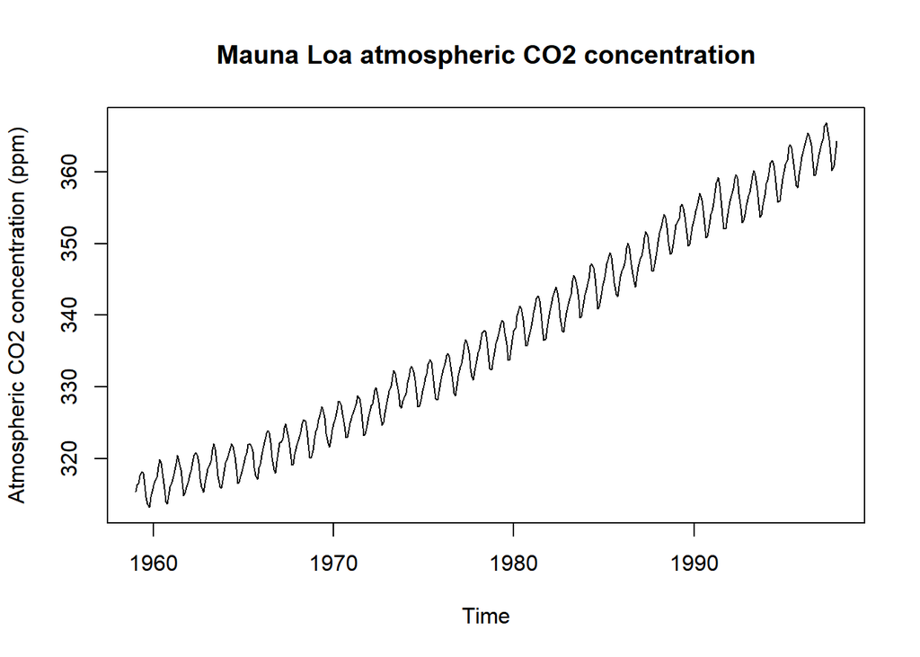

```r
plot(co2,
     ylab = "Atmospheric CO2 concentration (ppm)",
     main = "Mauna Loa atmospheric CO2 concentration")
```

We can see from this plot that the time series has a positive trend with clear seasonality. This can be shown more explicitly using the Brockwell and Davies algorithm, which can be implemented in R using the `decompose()` function.

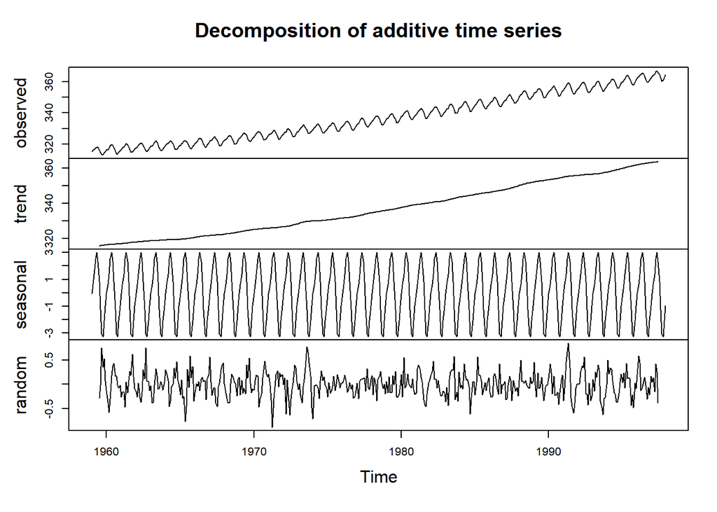

```r
plot(decompose(co2))
```

## 2.3 Trend

As previously stated, there is a clear positive trend that looks to be linear, therefore we will proceed with a linear regression model.

```r
# Create a linear regression model
co2.lm<-lm(co2~time(co2), na.action = NULL)
# Produce model summary statistics
summary(co2.lm)
```

```
##
## Call:
## lm(formula = co2 ~ time(co2), na.action = NULL)
##
## Residuals:
##     Min      1Q  Median      3Q     Max
## -6.0399 -1.9476 -0.0017  1.9113  6.5149
##
## Coefficients:
##               Estimate Std. Error t value Pr(>|t|)
## (Intercept) -2.250e+03  2.127e+01  -105.8   <2e-16 ***
## time(co2)    1.308e+00  1.075e-02   121.6   <2e-16 ***
## ---
## Signif. codes:  0 '***' 0.001 '**' 0.01 '*' 0.05 '.' 0.1 ' ' 1
##
## Residual standard error: 2.618 on 466 degrees of freedom
## Multiple R-squared:  0.9695, Adjusted R-squared:  0.9694
## F-statistic: 1.479e+04 on 1 and 466 DF,  p-value: < 2.2e-16
```

Looking at the model coefficients, the model estimates that the atmospheric CO2 concentration increases by 1.308ppm per year. Note that this is only an estimate as it does not take into account the seasonality, only the trend. This is made clear when we re-plot the time series with the model regression line.

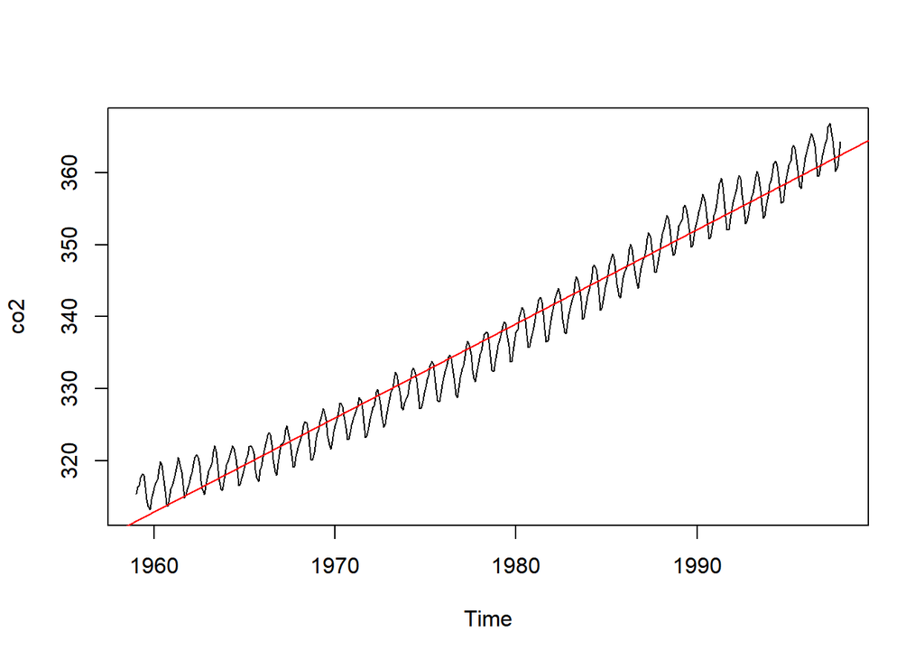

```r
# Re-plot the time series with the model regression line
plot(co2)
abline(co2.lm, col="red")
```

## 2.4 Seasonality

Observing the plots above, it is evident that there is yearly or close to yearly seasonality. Observing the raw data indicates that the highest values of atmospheric CO2 concentration were recorded around the middle of the year (May and June) and the lowest values around October. This pattern repeats itself consistently in each year.

# 3: Prophet Forecasting

## 3.1 Preparing to forecast

Before we continue, we must ensure that the correct packages are installed and the correct libraries loaded. We first want the load the library ‘prophet’; if this is your first time loading the library you will likely need to install the appropriate package first using `install.packages("prophet")`.

```r
# Loading the prophet library
library(prophet)
```

## 3.2 Formatting the data

For forecasting using prophet we want to ensure that the data is in the correct format, specifically a data frame with the times in a column labelled **ds** and the CO2 values in a column labelled **y**. We can do this using the function `data.frame()`. To extract the times from a time series object, we must use the function `time()`. We will also use the function `yearmon()` to write these times in the correct format, for which we will need to load the library **zoo**.

```r
# Load zoo library
library(zoo)
# Load the data frame and assign it to a variable
co2.df<-data.frame(ds = yearmon(time(co2)), y = co2)
# Use the head() function to check the data frame
head(co2.df)
```

```
##         ds      y
## 1 Jan 1959 315.42
## 2 Feb 1959 316.31
## 3 Mar 1959 316.50
## 4 Apr 1959 317.56
## 5 May 1959 318.13
## 6 Jun 1959 318.00
```

## 3.3 Making predictions

We can now proceed with making and plotting predictions using prophet. We want to make eight new predictions, in this case predictions for the next eight months. To do this we must specify this value in the function `make_future_dataframe()` as well as specifying the frequency (‘freq’) to be ‘month’.

```r
# Create the prophet model
prophet.model<-prophet(co2.df)
```

```
## Disabling weekly seasonality. Run prophet with weekly.seasonality=TRUE to override this.
```

```
## Disabling daily seasonality. Run prophet with daily.seasonality=TRUE to override this.
```

```r
# Create a data frame with future dates
future.df<-make_future_dataframe(prophet.model, 8, freq = "month")
# Create predictions using prophet model and data frame
forecast<-predict(prophet.model, future.df)
```

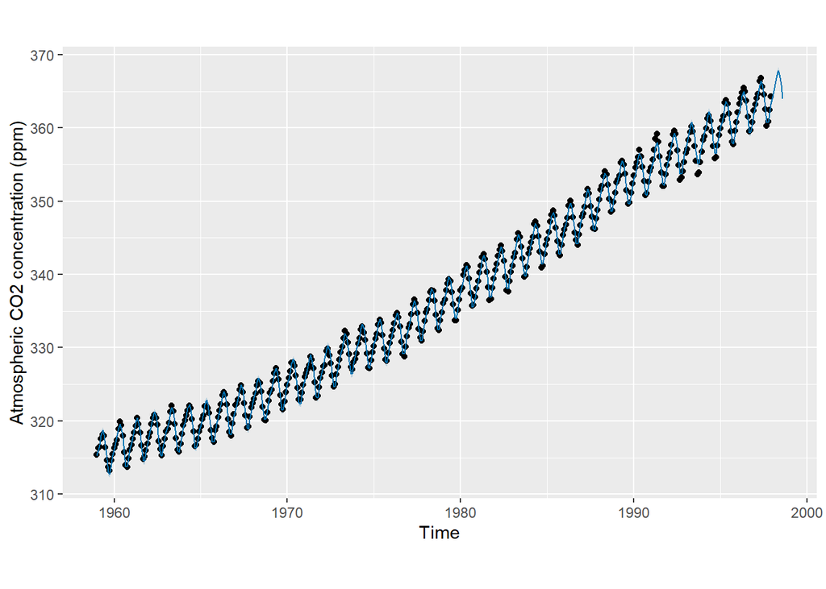

```r
# Plot the data with the future predictions
plot(prophet.model, forecast, xlab = "Time",
     ylab = "Atmospheric CO2 concentration (ppm)")
```

# References

- Atmospheric carbon dioxide & Mauna Loa: https://www.climate.gov/news-features/understanding-climate/climate-change-atmospheric-carbon-dioxide
- Guide to using prophet: https://cloud.r-project.org/web/packages/prophet/vignettes/quick_start.html
- Using prophet for forecasting: https://mode.com/example-gallery/forecasting_prophet_r_cookbook#forecasting
- Datacamp course: https://www.datacamp.com/courses/reporting-with-rmarkdown
- RStudio reference: https://rmarkdown.rstudio.com/lesson-1.html
- More sophisticated reference: https://bookdown.org/yihui/rmarkdown/